# Group 4 work

Nzambuli Daniel

2024-06-08

# Recode the data using the following parameters

1. ongoing -> 04/06/2024
2. AX -> END `sponsor of the patient` **Client**

# The data

```r
library(readxl)
Patient_Data = read_excel("Patient Data.xlsx")
View(Patient_Data)
```

```r
head(Patient_Data)
```

```
## # A tibble: 6 × 133
##    S.no Code  Facilty_Type Sex_Patient   Age Date_Started        Date_Ended
##   <dbl> <chr> <chr>        <chr>       <dbl> <dttm>              <chr>
## 1     1 LM001 Non Resident Female         79 2024-04-16 00:00:00 Ongoing
## 2     2 LM002 Non Resident Female         88 2022-12-06 00:00:00 Ongoing
## 3     3 LM003 Non Resident Female         84 2024-01-29 00:00:00 Ongoing
## 4     4 MT001 non Resident Female         82 2024-04-01 00:00:00 45410
## 5     5 MT002 Non Resident Male           75 2024-04-01 00:00:00 Ongoing
## 6     6 MT003 Non Resident Female         88 2024-03-01 00:00:00 Ongoing
## # ℹ 126 more variables: ...8 <chr>, Education <chr>, Race <chr>, Marital <chr>,
## #   Length_Separated <chr>, Household_Patient <chr>, Household_below5 <dbl>,
## #   `Household_5-18` <dbl>, Household_above18 <chr>, Level_Dependancy <chr>,
## #   Current_Condition...18 <chr>, Alcohol <chr>, Physical_Activities <chr>,
## #   Smoking <chr>, Processed_Food <chr>, Rate_Nusingcare <chr>,
## #   Rate_Medication <chr>, Meals <chr>, Infrastructure <chr>,
## #   Rate_Accessibility <chr>, Rate_Physiotherapy <chr>, …
```

### Convert dates to Date datatype

```r
as.Date(as.numeric(Patient_Data$Date_Ended), format =  "%Y-%m-%d", origin ="1899-12-30")
```

```
##   [1] NA           NA           NA           "2024-04-28" NA
##   [6] NA           NA           NA           NA           NA
##  [11] NA           "2024-04-01" NA           NA           NA
##  [16] NA           NA           "2024-01-26" NA           "2024-12-01"
##  [21] NA           "2024-05-31" "2024-01-31" NA           NA
##  [26] "2024-02-01" "2024-05-07" NA           NA           NA
##  [31] NA           NA           "2024-02-11" "2024-03-25" NA
##  [36] NA           NA           NA           NA           NA
##  [41] NA           NA           NA           NA           NA
##  [46] NA           NA           NA           NA           NA
##  [51] NA           NA           NA           NA           NA
##  [56] NA           "2023-05-19" "2023-09-05" "2022-09-01" "2023-11-27"
##  [61] NA           NA           "2023-07-31" NA           "2023-10-01"
##  [66] "2023-11-27" "2024-02-25" NA           "2023-10-15" NA
##  [71] NA           "2022-05-01" "2023-09-01" NA           NA
```

[output cut: 25 more lines]

### The conversion of Date ended

**Points to note**

- converting text to dates introduces NA for text data like `ongoing` which may be misleading when the data has its own NA values
- Setting the ongoing data to `04/06/2024` is chosen as the first step then the column will be converted to date data afterwards
- Noticed an entry `04/12/923` converting it to NA because it does not make logical sense. It makes a terrifying assumption of an individual that is `1101` years old.

```r
Patient_Data$Date_Ended[Patient_Data$Date_Ended == "04/12/923"] = NA
```

- clean the Facility Type data to have only two variables

```r
unique(Patient_Data$Facilty_Type)
```

```
## [1] "Non Resident" "non Resident" "Resident"     NA
```

```r
library(dplyr)
Patient_Data = Patient_Data %>% mutate(
  Facilty_Type = ifelse(Facilty_Type == "non Resident", "Non Resident", Facilty_Type)
)
Patient_Data$Facilty_Type = as.factor(Patient_Data$Facilty_Type)
```

```r
unique(Patient_Data$Facilty_Type)
```

```
## [1] Non Resident Resident     <NA>
## Levels: Non Resident Resident
```

### Cleaning the rest of the data

```r
library(dplyr)

# there is a challenge with casting in dplyr a step by step process is the best option

date = Patient_Data$Date_Ended

# Convert the date data with ongoing to "2024-06-04"
date[date == "Ongoing"] = "2024-06-04"

# convert all the data to numeric
# convert the numbers to dates
date_b = date[!is.na(date) & date != "2024-06-04"]
date[!is.na(date) & date != "2024-06-04"] = as.character(as.Date(as.numeric(date_b), origin = "1899-12-30"))

# format to standard date format
date
```

```
##   [1] "2024-06-04" "2024-06-04" "2024-06-04" "2024-04-28" "2024-06-04"
##   [6] "2024-06-04" "2024-06-04" "2024-06-04" "2024-06-04" "2024-06-04"
##  [11] "2024-06-04" "2024-04-01" "2024-06-04" "2024-06-04" "2024-06-04"
##  [16] "2024-06-04" "2024-06-04" "2024-01-26" NA           "2024-12-01"
##  [21] "2024-06-04" "2024-05-31" "2024-01-31" "2024-06-04" "2024-06-04"
##  [26] "2024-02-01" "2024-05-07" "2024-06-04" "2024-06-04" "2024-06-04"
##  [31] "2024-06-04" "2024-06-04" "2024-02-11" "2024-03-25" "2024-06-04"
##  [36] "2024-06-04" "2024-06-04" "2024-06-04" "2024-06-04" "2024-06-04"
##  [41] "2024-06-04" "2024-06-04" "2024-06-04" "2024-06-04" "2024-06-04"
##  [46] "2024-06-04" "2024-06-04" "2024-06-04" "2024-06-04" "2024-06-04"
##  [51] "2024-06-04" "2024-06-04" "2024-06-04" "2024-06-04" "2024-06-04"
##  [56] "2024-06-04" "2023-05-19" "2023-09-05" "2022-09-01" "2023-11-27"
##  [61] "2024-06-04" "2024-06-04" "2023-07-31" "2024-06-04" "2023-10-01"
##  [66] "2023-11-27" "2024-02-25" "2024-06-04" "2023-10-15" "2024-06-04"
##  [71] "2024-06-04" "2022-05-01" "2023-09-01" "2024-06-04" "2024-06-04"
```

[output cut: 25 more lines]

- potential issue: There is a date `12/1/2024` present in the data on the $20^{th}$ entry

```r
clean_Data = Patient_Data
clean_Data$Date_Ended = date

clean_Data = clean_Data %>%
  mutate(Date_Started = as.Date(Date_Started, format = "%Y-%m-%d"),
         Date_Ended = as.Date(Date_Ended, format = "%Y-%m-%d"))
head(clean_Data)
```

```
## # A tibble: 6 × 133
##    S.no Code  Facilty_Type Sex_Patient   Age Date_Started Date_Ended ...8
##   <dbl> <chr> <fct>        <chr>       <dbl> <date>       <date>     <chr>
## 1     1 LM001 Non Resident Female         79 2024-04-16   2024-06-04 <NA>
## 2     2 LM002 Non Resident Female         88 2022-12-06   2024-06-04 <NA>
## 3     3 LM003 Non Resident Female         84 2024-01-29   2024-06-04 <NA>
## 4     4 MT001 Non Resident Female         82 2024-04-01   2024-04-28 Died
## 5     5 MT002 Non Resident Male           75 2024-04-01   2024-06-04 <NA>
## 6     6 MT003 Non Resident Female         88 2024-03-01   2024-06-04 <NA>
## # ℹ 125 more variables: Education <chr>, Race <chr>, Marital <chr>,
## #   Length_Separated <chr>, Household_Patient <chr>, Household_below5 <dbl>,
## #   `Household_5-18` <dbl>, Household_above18 <chr>, Level_Dependancy <chr>,
## #   Current_Condition...18 <chr>, Alcohol <chr>, Physical_Activities <chr>,
## #   Smoking <chr>, Processed_Food <chr>, Rate_Nusingcare <chr>,
## #   Rate_Medication <chr>, Meals <chr>, Infrastructure <chr>,
## #   Rate_Accessibility <chr>, Rate_Physiotherapy <chr>, …
```

### Data with wrong imputation

This was noted because there was negative numbers in the duration of being in Care 360

```r
clean_Data[c(148, 140, 33, 58), ]$Date_Started
```

```
## [1] "2024-12-15" "2023-05-15" "2024-04-04" "2023-09-08"
```

```r
clean_Data[c(148, 140, 33, 58), ]$Date_Ended
```

```
## [1] "2024-06-04" "2023-02-15" "2024-02-11" "2023-09-05"
```

- `2024-12-15` is a patient that started later than the end date of the study. The patient data needs to be removed as it does not make logical sense

```r
clean_Data = clean_Data %>% filter(Date_Started <= Date_Ended)
head(clean_Data)
```

```
## # A tibble: 6 × 133
##    S.no Code  Facilty_Type Sex_Patient   Age Date_Started Date_Ended ...8
##   <dbl> <chr> <fct>        <chr>       <dbl> <date>       <date>     <chr>
## 1     1 LM001 Non Resident Female         79 2024-04-16   2024-06-04 <NA>
## 2     2 LM002 Non Resident Female         88 2022-12-06   2024-06-04 <NA>
## 3     3 LM003 Non Resident Female         84 2024-01-29   2024-06-04 <NA>
## 4     4 MT001 Non Resident Female         82 2024-04-01   2024-04-28 Died
## 5     5 MT002 Non Resident Male           75 2024-04-01   2024-06-04 <NA>
## 6     6 MT003 Non Resident Female         88 2024-03-01   2024-06-04 <NA>
## # ℹ 125 more variables: Education <chr>, Race <chr>, Marital <chr>,
## #   Length_Separated <chr>, Household_Patient <chr>, Household_below5 <dbl>,
## #   `Household_5-18` <dbl>, Household_above18 <chr>, Level_Dependancy <chr>,
## #   Current_Condition...18 <chr>, Alcohol <chr>, Physical_Activities <chr>,
## #   Smoking <chr>, Processed_Food <chr>, Rate_Nusingcare <chr>,
## #   Rate_Medication <chr>, Meals <chr>, Infrastructure <chr>,
## #   Rate_Accessibility <chr>, Rate_Physiotherapy <chr>, …
```

## Question 1

### Fit the survival function for the data and interpret the results

```r
library(survival)
library(survminer)
surv_Data = data.frame(duration = as.numeric(clean_Data$Date_Ended - clean_Data$Date_Started),
                       event_observed = ifelse(!is.na(clean_Data$Date_Ended) & clean_Data$Date_Ended != "2024-06-04", 1, 0))
head(surv_Data)
```

```
##   duration event_observed
## 1       49              0
## 2      546              0
## 3      127              0
## 4       27              1
## 5       64              0
## 6       95              0
```

#### Kaplan-Meier Fit

```r
clean_Data$duration = surv_Data$duration
clean_Data$event_observed = surv_Data$event_observed
```

```r
surv_obj = Surv(time = surv_Data$duration, event = surv_Data$event_observed)
km_fit = survfit(surv_obj~1, data = clean_Data)
```

#### Summary

```r
summary(km_fit)
```

```
## Call: survfit(formula = surv_obj ~ 1, data = clean_Data)
##
##  time n.risk n.event survival std.err lower 95% CI upper 95% CI
##     4    181       1    0.994 0.00551        0.984        1.000
##     5    180       1    0.989 0.00777        0.974        1.000
##     6    178       1    0.983 0.00951        0.965        1.000
##     7    177       2    0.972 0.01222        0.949        0.997
##     8    175       1    0.967 0.01336        0.941        0.993
##     9    174       1    0.961 0.01439        0.933        0.990
##    10    173       1    0.956 0.01534        0.926        0.986
##    13    170       2    0.944 0.01710        0.911        0.978
##    21    167       1    0.939 0.01790        0.904        0.974
##    25    165       1    0.933 0.01868        0.897        0.970
##    27    164       1    0.927 0.01941        0.890        0.966
##    28    162       1    0.922 0.02012        0.883        0.962
```

[output cut: 33 more lines]

```
1. n.risk: The number of people at risk of experiencing death just before the given number of days from the begining of the experiment.

2. n.event: The number of deaths that occurred at the given time.

3. survival: The estimated survival probability at the given time.

4. std.err: The standard error of the estimated survival probability.

5. lower 95% CI: The lower bound of the 95% confidence interval for the survival probability.

6. upper 95% CI: The upper bound of the 95% confidence interval for the survival probability.
```

#### Plot

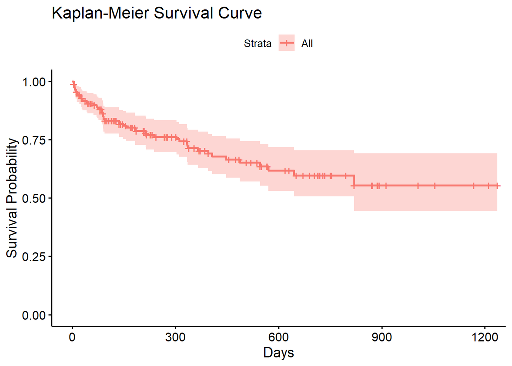

```r
ggsurvplot(km_fit, data = clean_Data,
           xlab = "Days",
           ylab = "Survival Probability",
           title = "Kaplan-Meier Survival Curve")
```

```r
clean_resident = clean_Data %>% filter(Facilty_Type == "Resident")
clean_non_resident = clean_Data %>% filter(Facilty_Type == "Non Resident")
```

#### Split to resident

```r
km_fit_resident = survfit(Surv(time = duration, event = event_observed)~1, data = clean_resident)
summary(km_fit_resident)
```

```
## Call: survfit(formula = Surv(time = duration, event = event_observed) ~
##     1, data = clean_resident)
##
##  time n.risk n.event survival std.err lower 95% CI upper 95% CI
##    62     19       1    0.947  0.0512        0.852        1.000
##    77     18       1    0.895  0.0704        0.767        1.000
##    89     17       1    0.842  0.0837        0.693        1.000
##    90     16       2    0.737  0.1010        0.563        0.964
##   214     12       1    0.675  0.1097        0.491        0.929
##   396      8       1    0.591  0.1243        0.391        0.893
##   407      7       1    0.507  0.1321        0.304        0.845
##   447      6       1    0.422  0.1344        0.226        0.788
##   487      5       1    0.338  0.1314        0.158        0.724
```

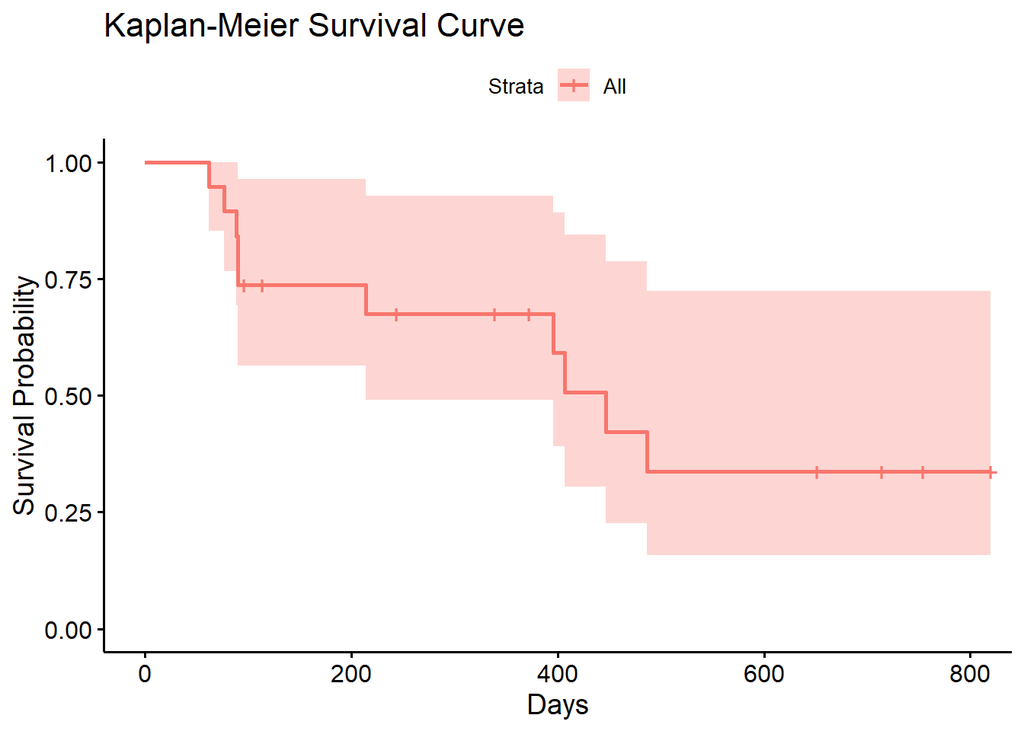

```r
ggsurvplot(km_fit_resident, data = clean_resident,
           xlab = "Days",
           ylab = "Survival Probability",
           title = "Kaplan-Meier Survival Curve")
```

#### Split to non resident

```r
km_fit_non_resident = survfit(Surv(time = duration, event = event_observed)~1, data = clean_non_resident)
summary(km_fit_non_resident)
```

```
## Call: survfit(formula = Surv(time = duration, event = event_observed) ~
##     1, data = clean_non_resident)
##
##  time n.risk n.event survival std.err lower 95% CI upper 95% CI
##     4    162       1    0.994 0.00615        0.982        1.000
##     5    161       1    0.988 0.00868        0.971        1.000
##     6    159       1    0.981 0.01061        0.961        1.000
##     7    158       2    0.969 0.01364        0.943        0.996
##     8    156       1    0.963 0.01490        0.934        0.992
##     9    155       1    0.957 0.01605        0.926        0.989
##    10    154       1    0.950 0.01710        0.917        0.985
##    13    151       2    0.938 0.01905        0.901        0.976
##    21    148       1    0.931 0.01995        0.893        0.971
##    25    146       1    0.925 0.02081        0.885        0.967
##    27    145       1    0.919 0.02162        0.877        0.962
```

[output cut: 25 more lines]

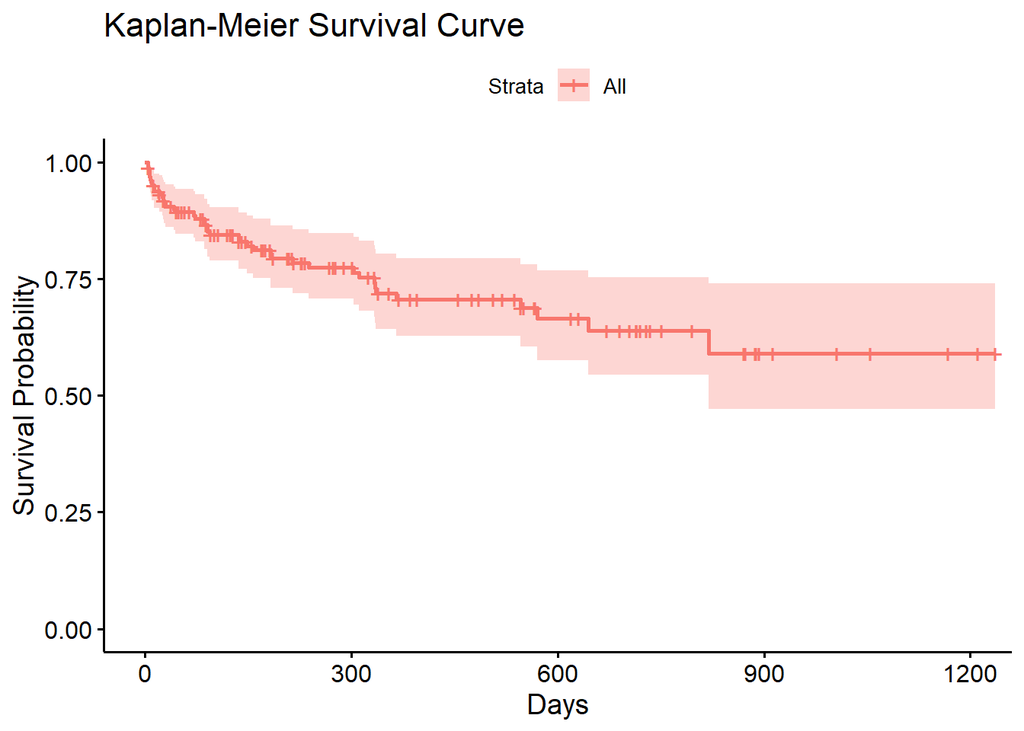

```r
ggsurvplot(km_fit_non_resident, data = clean_non_resident,
           xlab = "Days",
           ylab = "Survival Probability",
           title = "Kaplan-Meier Survival Curve")
```

### Fit the hazard function for the data and interpret the results

Meant to show when the risk of experiencing an event is highest

#### A cox proportional Hazard

```r
haz_fit = coxph(surv_obj~1, data = clean_Data)

# baseline hazard function
base_haz = basehaz(haz_fit, centered = F)

summary(haz_fit)
```

```
## Call:  coxph(formula = surv_obj ~ 1, data = clean_Data)
##
## Null model
##   log likelihood= -243.8446
##   n= 181
```

This output represents a baseline model from which we can infer whether later models fit the data better.

- this will be assessed by getting log likelihood values that are $-243.8446 \lt$

#### Plot the hazard function

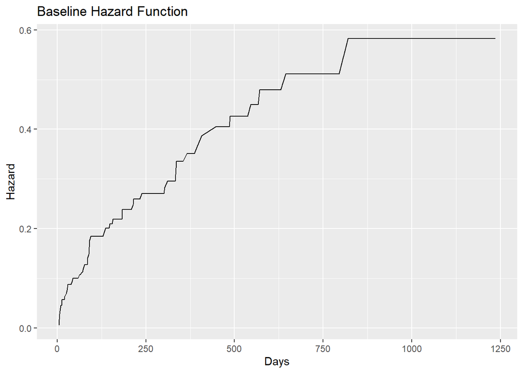

```r
ggplot(base_haz, aes(x = time, y = hazard))+
  geom_line()+
  labs(x = "Days",
       y = "Hazard",
       title = "Baseline Hazard Function")
```

**Interpretation**

The plateaus in the graph indicate periods where there are minimal changes to the population.

The plateau after day 800 indicates that after that day most of the population did not experience a new death case.

large magnitudes in the spikes like on day 100, 400 and 800 may indicate a potential pattern that may need further study to ascertain the type of intervention to be made to help mitigate the spike in deaths on those periods

#### Split View Resident

```r
haz_fit_resident = coxph(Surv(time = duration, event = event_observed)~1, data = clean_resident)

base_haz_resident = basehaz(haz_fit_resident, centered = F)

summary(haz_fit_resident)
```

```
## Call:  coxph(formula = Surv(time = duration, event = event_observed) ~
##     1, data = clean_resident)
##
## Null model
##   log likelihood= -24.06012
##   n= 19
```

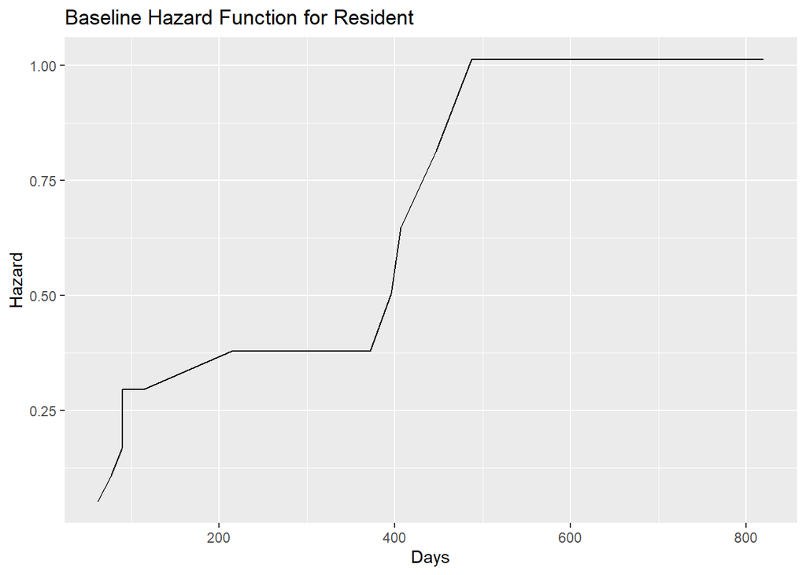

```r
ggplot(base_haz_resident, aes(x = time, y = hazard))+
  geom_line()+
  labs(x = "Days",
       y = "Hazard",
       title = "Baseline Hazard Function for Resident")
```

#### Split View Non Resident

```r
haz_fit_non_resident = coxph(Surv(time = duration, event = event_observed)~1, data = clean_non_resident)

base_haz_non_resident = basehaz(haz_fit_non_resident, centered = F)

summary(haz_fit_non_resident)
```

```
## Call:  coxph(formula = Surv(time = duration, event = event_observed) ~
##     1, data = clean_non_resident)
##
## Null model
##   log likelihood= -193.4372
##   n= 162
```

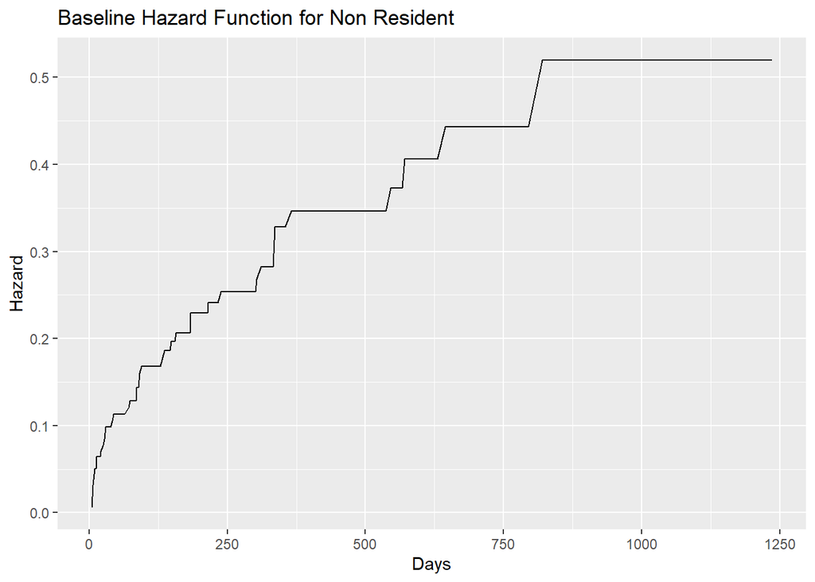

```r
ggplot(base_haz_non_resident, aes(x = time, y = hazard))+
  geom_line()+
  labs(x = "Days",
       y = "Hazard",
       title = "Baseline Hazard Function for Non Resident")
```

### Fit the cumulative hazard function and interpret the results

#### Nelson-Alen

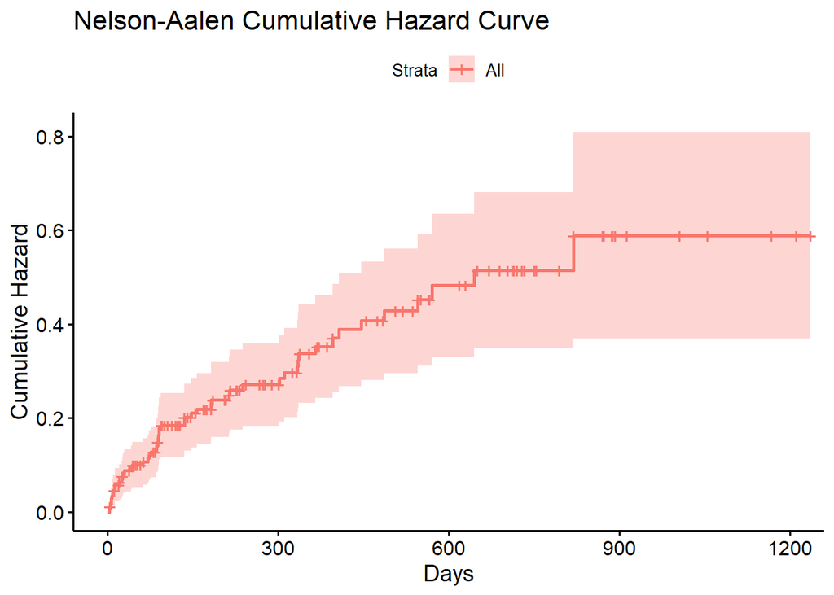

```r
library(survival)
ggsurvplot(km_fit, fun = "cumhaz",
           xlab = "Days",
           ylab = "Cumulative Hazard",
           title = "Nelson-Aalen Cumulative Hazard Curve")
```

#### Split to resident

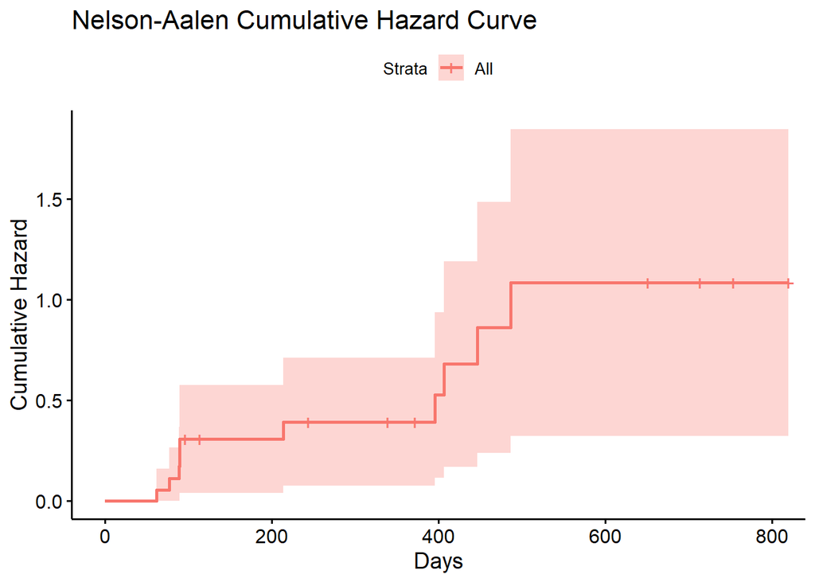

```r
ggsurvplot(km_fit_resident, fun = "cumhaz",
           xlab = "Days",
           ylab = "Cumulative Hazard",
           title = "Nelson-Aalen Cumulative Hazard Curve")
```

#### Split to non resident

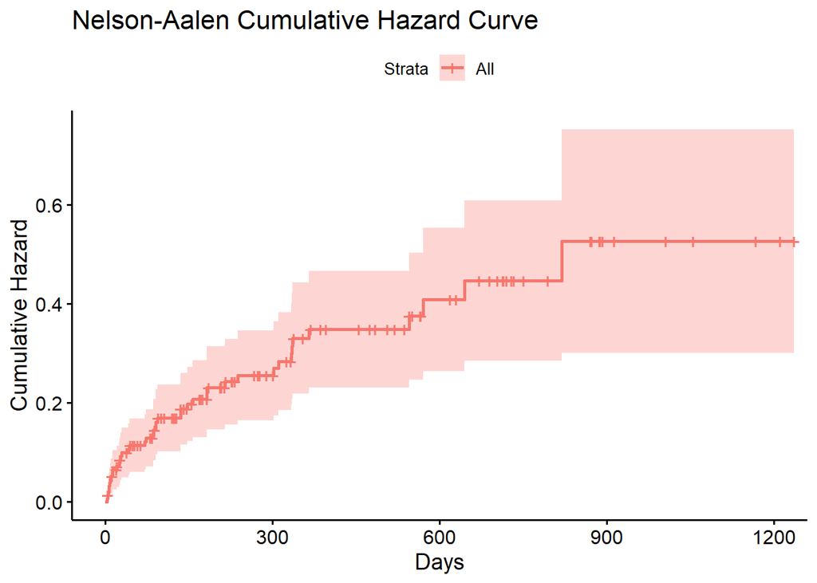

```r
ggsurvplot(km_fit_non_resident, fun = "cumhaz",
           xlab = "Days",
           ylab = "Cumulative Hazard",
           title = "Nelson-Aalen Cumulative Hazard Curve")
```

### Re-code the columns AN, AO, AP, AQ, AR, AS, AT, AU, AV to have

> Not Difficult [0]

> Somewhat [1]

> Very Difficult [2]

> Extremely Difficult [3]

### Then introduce a new variable of the sum such that if the sum is

> | sum | Meaning |
> | --- | --- |
> | 0- 4 | None/ minimal |
> | 5-9 | mild depressed |
> | 10-14 | moderate depressed |
> | 15-19 | moderate severe |
> | 20-27 | severe depression |

### Get the unique values in each column

```r
cols_depression = c("Pleasure_doingthings", "Depressed", "Sleep", "Energy",      "Appetite", "Bad_About_Myself", "Concentration", "Speak_Slowly",            "Thoughts")

unique_values = lapply(clean_Data[cols_depression], unique)

unique_values
```

```
## $Pleasure_doingthings
## [1] "Somewhat"            "Very difficult"      "Extremely difficult"
## [4] "Not difficult"       NA
##
## $Depressed
## [1] "Not difficult"       "Very difficult"      "Somewhat"
## [4] "Extremely difficult" NA
##
## $Sleep
## [1] "Somewhat"            "Not difficult"       "Very difficult"
## [4] "Extremely difficult" "S"                   NA
## [7] "s"
##
## $Energy
## [1] "Somewhat"            "Not difficult"       "Extremely difficult"
## [4] "Very difficult"      "E"                   NA
## [7] "e"
##
## $Appetite
## [1] "Not difficult"       "Somewhat"            "Extremely difficult"
## [4] "Very difficult"      NA
##
## $Bad_About_Myself
## [1] "Not difficult"       "Very difficult"      "Somewhat"
## [4] "Extremely difficult" NA
##
## $Concentration
## [1] "Very difficult"      "Extremely difficult" "Nof difficult"
## [4] "Somewhat"            NA                    "Not difficult"
## [7] "n"
##
## $Speak_Slowly
## [1] "Not difficult"       "Extremely difficult" "Somewhat"
## [4] "Very difficult"      NA                    "s"
##
## $Thoughts
## [1] "Not difficult"       NA                    "Very difficult"
## [4] "Extremely difficult" "Somewhat"
```

### Recode the column names

```r
clean_Data <- clean_Data %>%
  mutate(across(all_of(cols_depression), ~ case_when(
    .x %in% c("s", "S") ~ "Somewhat",
    .x %in% c("n", "N") ~ "Not difficult",
    .x %in% c("e", "E") ~ "Extremely difficult",
    TRUE ~ .x
  )))
```

```r
unique_values = lapply(clean_Data[cols_depression], unique)

unique_values
```

```
## $Pleasure_doingthings
## [1] "Somewhat"            "Very difficult"      "Extremely difficult"
## [4] "Not difficult"       NA
##
## $Depressed
## [1] "Not difficult"       "Very difficult"      "Somewhat"
## [4] "Extremely difficult" NA
##
## $Sleep
## [1] "Somewhat"            "Not difficult"       "Very difficult"
## [4] "Extremely difficult" NA
##
## $Energy
## [1] "Somewhat"            "Not difficult"       "Extremely difficult"
## [4] "Very difficult"      NA
##
## $Appetite
## [1] "Not difficult"       "Somewhat"            "Extremely difficult"
## [4] "Very difficult"      NA
##
## $Bad_About_Myself
## [1] "Not difficult"       "Very difficult"      "Somewhat"
## [4] "Extremely difficult" NA
##
## $Concentration
## [1] "Very difficult"      "Extremely difficult" "Nof difficult"
## [4] "Somewhat"            NA                    "Not difficult"
##
## $Speak_Slowly
## [1] "Not difficult"       "Extremely difficult" "Somewhat"
## [4] "Very difficult"      NA
##
## $Thoughts
## [1] "Not difficult"       NA                    "Very difficult"
## [4] "Extremely difficult" "Somewhat"
```

### Recode columns to numeric and find the row sum

```r
clean_Data = clean_Data %>%
  mutate(across(all_of(cols_depression), ~ ifelse(.x == "Not difficult", 0,
                                         ifelse(.x == "Somewhat", 1,
                                         ifelse(.x == "Very difficult", 2,
                                         ifelse(.x == "Extremely difficult", 3, NA))))))
```

```r
unique_values = lapply(clean_Data[cols_depression], unique)

unique_values
```

```
## $Pleasure_doingthings
## [1]  1  2  3  0 NA
##
## $Depressed
## [1]  0  2  1  3 NA
##
## $Sleep
## [1]  1  0  2  3 NA
##
## $Energy
## [1]  1  0  3  2 NA
##
## $Appetite
## [1]  0  1  3  2 NA
##
## $Bad_About_Myself
## [1]  0  2  1  3 NA
##
## $Concentration
## [1]  2  3 NA  1  0
##
## $Speak_Slowly
## [1]  0  3  1  2 NA
##
## $Thoughts
## [1]  0 NA  2  3  1
```

### Create a new column of the rowwise sum

```r
clean_Data = clean_Data %>% rowwise() %>%
  mutate(dep_ind = sum(c_across(all_of(cols_depression)), na.rm = TRUE)) %>%
  ungroup()

depression_index = as.data.frame(table(clean_Data$dep_ind))
depression_index
```

```
##    Var1 Freq
## 1     0   19
## 2     1    3
## 3     2    4
## 4     3    4
## 5     4   16
## 6     5   13
## 7     6   13
## 8     7   15
## 9     8   12
## 10    9    7
## 11   10   15
## 12   11    6
## 13   12    6
## 14   14    7
## 15   15    6
## 16   16    5
## 17   17    5
## 18   18    7
## 19   19    5
## 20   21    2
## 21   22    3
## 22   23    1
## 23   24    2
## 24   25    1
## 25   27    4
```

### Recode the depression column

```r
clean_Data = clean_Data %>% mutate(dep_lvl = case_when(
  dep_ind >= 0 & dep_ind <= 4 ~ "None_minimal",
  dep_ind >= 5 & dep_ind <= 9 ~ "Mild Depression",
  dep_ind >= 10 & dep_ind <= 14 ~ "Moderate Depression",
  dep_ind >= 15 & dep_ind <= 19 ~ "Moderate Severe",
  dep_ind >= 20 & dep_ind <= 27 ~ "Severe Depression",
  T~ NA_character_
))

depression_level = as.data.frame(table(clean_Data$dep_lvl))
depression_level
```

```
##                  Var1 Freq
## 1     Mild Depression   60
## 2 Moderate Depression   34
## 3     Moderate Severe   28
## 4        None_minimal   46
## 5   Severe Depression   13
```

## Question 2

### Using appropriate visualization techniques, present the relationship between Age of patient and age of client/ caregiver

```r
library(tidyverse)
ages <- clean_Data %>% select(Age, Age_Client)
summary(ages)
```

```
##       Age          Age_Client
##  Min.   :29.00   Min.   :20.00
##  1st Qu.:69.75   1st Qu.:47.00
##  Median :79.00   Median :55.50
##  Mean   :76.56   Mean   :56.38
##  3rd Qu.:88.00   3rd Qu.:65.00
##  Max.   :98.00   Max.   :94.00
##  NA's   :1       NA's   :5
```

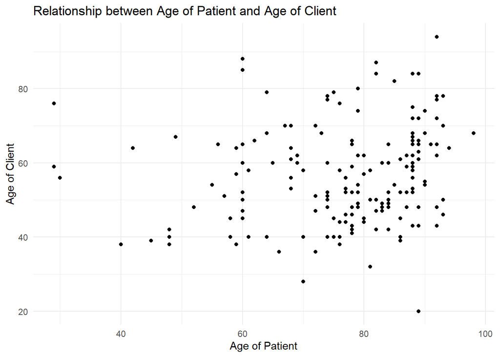

```r
ggplot(ages, aes(x = Age, y = Age_Client)) +
  geom_point() +
  labs(title = "Relationship between Age of Patient and Age of Client",
       x = "Age of Patient",
       y = "Age of Client") +
  theme_minimal()
```

From the graph it appears there is no relationship between the age of the client and the age of the patient. This is because there is no recognizable pattern in the graph

```r
cor(ages)
```

```
##            Age Age_Client
## Age          1         NA
## Age_Client  NA          1
```

```r
cov(ages)
```

```
##            Age Age_Client
## Age         NA         NA
## Age_Client  NA         NA
```

### For Q41: Which disease or medical conditions did the patient have before being admitted at Care 360? (tick that applies). See columns BN, BP, BR, BT, BV, BX, BZ, CB, CD, CF, CH, CJ, CL, CN, CP, CR, CT, CV

#### DO bar chart frequencies for the categories

> 1. Chronic Cardiac disease (not hypertension)
> 2. Hypertension
> 3. Chronic pulmonary disease including Asthma/ Bronchitis/COPD
> 4. Chronic Kidney Disease
> 5. Obesity
> 6. Liver Disease
> 7. Chronic neurological disorder
> 8. Diabetes Mellitus
> 9. Rheumatologic disorder
> 10. Tuberculosis
> 11. HIV and AIDS
> 12. Arthritis
> 13. Stroke
> 14. Cancer
> 15. Mental health including depression and anxiety
> 16. Advanced Age
> 17. After Surgery
> 18. Fracture

```r
diseases = Patient_Data %>%
  select(Facilty_Type,
         Cardiac_Condition,
         Hypertention_Condition,
         Pulmonary_Condition,
         Kidney_Condition...72,
         Obesity,
         Liver_Condition,
         Neurological_Disorder,
         Diabetes,
         Rheumatology,
         TB,
         HIV,
         Athritis,
         Stroke,
         Cancer,
         `Mental and Dementia`,
         Advanced_Age,
         After_Surgery,
         Fracture)


long_diseases = diseases %>%
  pivot_longer(cols = -Facilty_Type, names_to = "Condition", values_to = "Presence")
long_diseases
```

```
## # A tibble: 3,564 × 3
##    Facilty_Type Condition              Presence
##    <fct>        <chr>                  <chr>
##  1 Non Resident Cardiac_Condition      <NA>
##  2 Non Resident Hypertention_Condition Yes
##  3 Non Resident Pulmonary_Condition    <NA>
##  4 Non Resident Kidney_Condition...72  <NA>
##  5 Non Resident Obesity                <NA>
##  6 Non Resident Liver_Condition        <NA>
##  7 Non Resident Neurological_Disorder  <NA>
##  8 Non Resident Diabetes               Yes
##  9 Non Resident Rheumatology           <NA>
## 10 Non Resident TB                     <NA>
## # ℹ 3,554 more rows
```

```r
condition_counts <- long_diseases %>%
  filter(Presence == "Yes") %>%
  count(Condition, Facilty_Type, sort = TRUE)



condition_counts
```

```
## # A tibble: 33 × 3
##    Condition              Facilty_Type     n
##    <chr>                  <fct>        <int>
##  1 Hypertention_Condition Non Resident    89
##  2 Advanced_Age           Non Resident    75
##  3 Diabetes               Non Resident    58
##  4 Pulmonary_Condition    Non Resident    43
##  5 After_Surgery          Non Resident    39
##  6 Athritis               Non Resident    38
##  7 Fracture               Non Resident    30
##  8 Cardiac_Condition      Non Resident    29
##  9 Mental and Dementia    Non Resident    29
## 10 Stroke                 Non Resident    23
## # ℹ 23 more rows
```

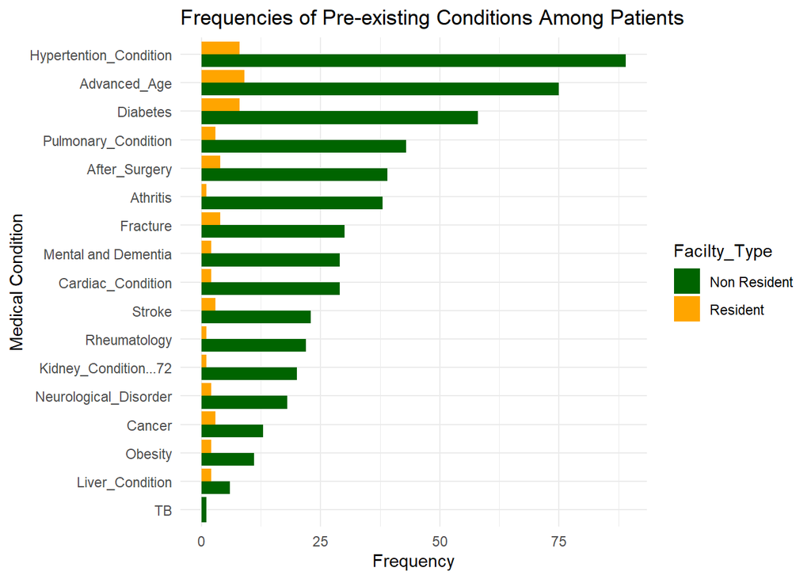

```r
ggplot(condition_counts, aes(x = reorder(Condition, n), y = n, fill = Facilty_Type)) +
  geom_bar(stat = "identity", position = "dodge") +
   scale_fill_manual(values = c("Resident" = "orange", "Non Resident" = "darkgreen")) +
  coord_flip() +
  labs(title = "Frequencies of Pre-existing Conditions Among Patients",
       x = "Medical Condition",
       y = "Frequency") +
  theme_minimal()
```

### For Q.43: At Care 360, did they detect any health condition which the patient was not aware of before -merge Not Sure and No-.For those who said yes do a barchart on the frequency for column CZ, DA, DB, DC, DD, DE, DF, DG, DH, DI, DJ, DK, DL, DM, DN, DO, DP

```r
Patient_Data <- Patient_Data %>%
  mutate(Other_Detected = ifelse(!is.na(Other_Detected) & Other_Detected != "", "Yes", "No"))

selected_columns <- Patient_Data %>%
  select(Facilty_Type,
         Cardiac_Detected,
         Hypertention_Detected,
         Pulmonary_Detected,
         Kidney_Condition...107,
         Obesity_Detected,
         Liver_Detected,
         Neurological_Detected,
         Diabetes_Detected,
         Rheumatology_Detected,
         TB_Detected,
         HIV_Detected,
         Athritis_Detected,
         Stroke_Detected,
         Cancer_Detected,
         Mental_Detected,
         Age_Detected,
         Other_Detected)

long_detected <- selected_columns %>%
  pivot_longer(cols = -Facilty_Type, names_to = "Condition", values_to = "Presence")
long_detected
```

```
## # A tibble: 3,366 × 3
##    Facilty_Type Condition              Presence
##    <fct>        <chr>                  <chr>
##  1 Non Resident Cardiac_Detected       <NA>
##  2 Non Resident Hypertention_Detected  <NA>
##  3 Non Resident Pulmonary_Detected     <NA>
##  4 Non Resident Kidney_Condition...107 <NA>
##  5 Non Resident Obesity_Detected       <NA>
##  6 Non Resident Liver_Detected         <NA>
##  7 Non Resident Neurological_Detected  <NA>
##  8 Non Resident Diabetes_Detected      <NA>
##  9 Non Resident Rheumatology_Detected  <NA>
## 10 Non Resident TB_Detected            <NA>
## # ℹ 3,356 more rows
```

```r
detected_condition_counts <- long_detected %>%
  filter(Presence == "Yes") %>%
  count(Condition,Facilty_Type, sort = TRUE)

detected_condition_counts = na.omit(detected_condition_counts)
detected_condition_counts
```

```
## # A tibble: 16 × 3
##    Condition             Facilty_Type     n
##    <chr>                 <fct>        <int>
##  1 Other_Detected        Non Resident     8
##  2 Mental_Detected       Non Resident     5
##  3 Hypertention_Detected Non Resident     4
##  4 Neurological_Detected Non Resident     3
##  5 Athritis_Detected     Non Resident     2
##  6 Athritis_Detected     Resident         2
##  7 Diabetes_Detected     Non Resident     2
##  8 Mental_Detected       Resident         2
##  9 Age_Detected          Non Resident     1
## 10 Cancer_Detected       Non Resident     1
## 11 Cardiac_Detected      Non Resident     1
## 12 Hypertention_Detected Resident         1
## 13 Obesity_Detected      Resident         1
## 14 Pulmonary_Detected    Non Resident     1
## 15 Pulmonary_Detected    Resident         1
## 16 Stroke_Detected       Resident         1
```

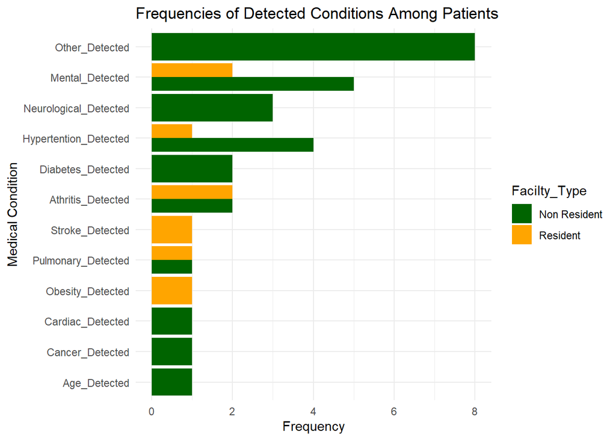

```r
ggplot(detected_condition_counts, aes(x = reorder(Condition, n), y = n, fill = Facilty_Type)) +
  geom_bar(stat = "identity", position = "dodge") +
   scale_fill_manual(values = c("Resident" = "orange", "Non Resident" = "darkgreen")) +
  coord_flip() +
  labs(title = "Frequencies of Detected Conditions Among Patients",
       x = "Medical Condition",
       y = "Frequency") +
  theme_minimal()
```

```r
columns_int = c("Cardiac_Detected",
         "Hypertention_Detected",
         "Pulmonary_Detected",
         "Kidney_Condition...107",
         "Obesity_Detected",
         "Liver_Detected",
         "Neurological_Detected",
         "Diabetes_Detected",
         "Rheumatology_Detected",
         "TB_Detected",
         "HIV_Detected",
         "Athritis_Detected",
         "Stroke_Detected",
         "Cancer_Detected",
         "Mental_Detected",
         "Age_Detected",
         "Other_Detected")
```

#### Fit the model

```r
library(survminer)
fit_km = function(column, df){
  formula <- as.formula(paste("Surv(time = duration, event = event_observed)~", column))
  tryCatch({
    km_trt_fit <- survfit(formula, data = df)
    print(paste("successful fit for: ", column))
  }, error = function(e) {
    print(paste("Error in survfit for column:", column))
  })
  tryCatch({
    print(autoplot(km_trt_fit, times = c(1,200,600,820), main = paste("Survival plot for: ", column)))
  }, error = function(e) {
    print(paste("Error in ggsurvplot for column:", column))
  })

}
```

```r
for(column in columns_int){
  df <- clean_Data %>%
    mutate(!!column := as.factor(ifelse(.data[[column]] == "Yes", 1, 0)))
  fit_km(column, df)

}
```

[output not shown]

[output cut: 19 more lines]

### Summarise the variable : Q.35: What is the main reason that made you bring your patient to care 360 column BH